# Lecture Notes

Sitta

2021-03-16

## RStudio’s panels

[figure not shown]

Source: https://bookdown.org/ndphillips/YaRrr/

## About RMarkdown

```r
# this is chunk, a place where you can write code
```

this is where you can write a note about your code

Example:

```r
1+1 # this is how you write a comment on a chunk
```

```
## [1] 2
```

To run your code, you can just click the green triangle button or just `ctrl + enter` or `command + enter` on your keyboard.

### Object

To save an object to your environment, you should assign the values to the object by using `<-` operator.

## Scalar, vector, matrix, dan Data Frame

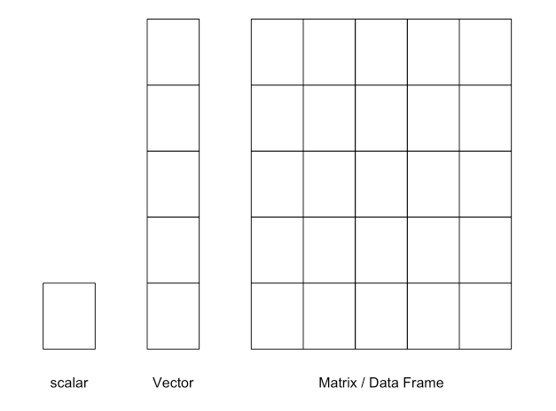

Source: https://bookdown.org/ndphillips/YaRrr/

### Scalar

The object where you have dimension 1 x 1

### Vector

The object where you have dimension n x 1 or 1 x n

### Data types

#### Character

```r
char <- c("Algoritma", "Data", "Science")
char
```

```
## [1] "Algoritma" "Data"      "Science"
```

```r
class(char)
```

```
## [1] "character"
```

#### Numeric

```r
num <- c(1,2,4,7.5)
num
```

```
## [1] 1.0 2.0 4.0 7.5
```

```r
class(num)
```

```
## [1] "numeric"
```

#### Integer

```r
int <- c(3L, 7L, 5L)
int
```

```
## [1] 3 7 5
```

```r
class(int)
```

```
## [1] "integer"
```

#### Logical

```r
logi <- c(TRUE, FALSE, T, F)
logi
```

```
## [1]  TRUE FALSE  TRUE FALSE
```

```r
class(logi)
```

```
## [1] "logical"
```

### List

Lists are a step up in complexity from atomic vectors, because lists can contain other lists

```r
obj_list <- list(c(2,3,4), c("jupyter", "night", "a"), c(T, F))
obj_list
```

```
## [[1]]
## [1] 2 3 4
##
## [[2]]
## [1] "jupyter" "night"   "a"
##
## [[3]]
## [1]  TRUE FALSE
```

```r
class(obj_list)
```

```
## [1] "list"
```

### Matrix dan Data Frame

The object where you have dimension n x n

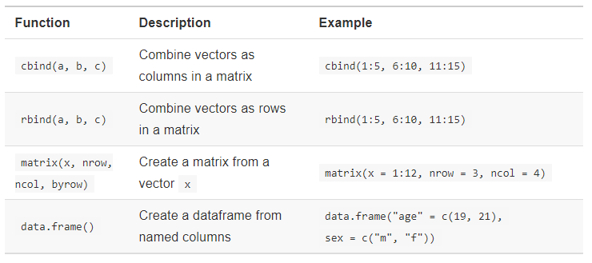

Source: https://bookdown.org/ndphillips/YaRrr/

## Explicit coercion

- `as.character()` untuk mengubah menjadi character
- `as.numeric()` untuk mengubah menjadi numeric
- `as.interger()` untuk mengubah menjadi integer
- `as.logical()` untuk mengubah menjadi logical
- `as.factor()` untuk mengubah menjadi factor
- `as.Date()` untuk mengubah menjadi date

## Where to seek help

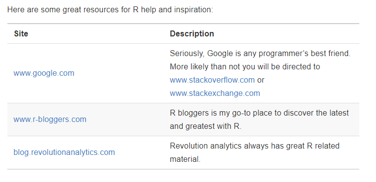

Source: https://bookdown.org/ndphillips/YaRrr/

## Cara untuk membuat .RProj

### Tahapan membuat .RProj ketika **belum** mempunyai folder untuk .RProj

- Klik menu File
- New Project
- New Directory
- New Project
- Isi directory name
- Specify working directory path yang diinginkan

### Tahapan membuat .RProj ketika **sudah** mempunyai folder untuk .RProj

- Klik menu File
- New Project
- Existing Directory
- Tentukan RProj ingin diletakkan di folder apa (Specify Working Directory)

## Eksplorasi dataset

### Membaca data dalam format `.csv`

```r
retail <- read.csv("data_input/retail.csv")
```

### Investigasi data

Investigasi data bisa dilakukan dengan `head()`, `tail()`, `str()`, atau `summary()`.

- `head()` untuk melihat 6 data awal
- `tail()` untuk melihat 6 data akhir
- `str()` untuk melihat struktur data
- `summary()` untuk melihat ringkasan dari data

### Fungsi `as.Date()`

Fungsi `as.Date()` berfungsi untuk mengubah data menjadi tipe tanggal. Hal yang perlu diperhatikan saat mengubah data ke bentuk tanggal adalah format awal pada data asli.

Note untuk as.Date:  
- `%d` = untuk tanggal  
- `%m` = untuk bulan (dalam angka)  
- `%B` = untuk bulan (dalam huruf)  
- `%b` = untuk bulan (dalam huruf (abbreviation))  
- `%y` = untuk tahun (dua angka)  
- `%Y` = untuk tahun (empat angka)

### Subsetting

Untuk mensubset dari data frame, bisa digunakan **nama_data[baris yang ingin disubset, kolom yang ingin disubset]** Ketika sebelah kanan tanda koma dikosongkan, `nama_data[baris, ]` artinya kita mengambil semua kolom, dan ketika sebelah kiri tanda koma dikosongkan, artinya kita mengambil semua baris

Contoh: ambillah 6 data awal dari kolom Sales, Profit

```r
retail[1:6, c("Sales", "Profit")]
```

|  | Sales | Profit |
| --- | --- | --- |
| 1 | 261.9600 | 41.9136 |
| 2 | 731.9400 | 219.5820 |
| 3 | 14.6200 | 6.8714 |
| 4 | 957.5775 | -383.0310 |
| 5 | 22.3680 | 2.5164 |
| 6 | 48.8600 | 14.1694 |

#### Subsetting operator

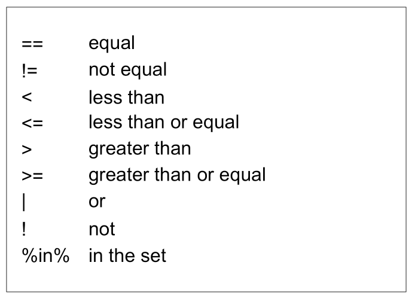

https://bookdown.org/ndphillips/YaRrr/logical-indexing.html

### table() dan prop.table()

Multiple Frequency Table dari `Ship.Mode` dan `Category`

```r
table(retail$Ship.Mode, retail$Category)
```

```
##
##                  Furniture Office Supplies Technology
##   First Class          327             910        301
##   Same Day             119             326         98
##   Second Class         427            1152        366
##   Standard Class      1248            3638       1082
```

Melihat proporsi dari Ship.Mode dan Category

```r
prop.table(table(retail$Ship.Mode, retail$Category),
           margin = 2)
```

```
##
##                   Furniture Office Supplies Technology
##   First Class    0.15417256      0.15101228 0.16296697
##   Same Day       0.05610561      0.05409890 0.05305901
##   Second Class   0.20132013      0.19117159 0.19815918
##   Standard Class 0.58840170      0.60371723 0.58581483
```

Note:  
- argumen `margin = 1` untuk menjumlahkan perbaris (membuat proporsi yang jumlahnya 1), kalau `margin = 2` perkolom  
- fungsi `table()` hanya memberikan output berupa frekuensi kemunculan datanya, jika ingin melihat deskripsi statistiknya (mean, max, min, median, sum), bisa menggunakan fungsi aggregate()

### Aggregasi data

```r
aggregate(Profit ~ Ship.Mode + Category,
          data = retail,
          FUN = max)
```

| Ship.Mode | Category | Profit |
| --- | --- | --- |
| First Class | Furniture | 673.8816 |
| Same Day | Furniture | 373.7790 |
| Second Class | Furniture | 700.9800 |
| Standard Class | Furniture | 1013.1270 |
| First Class | Office Supplies | 1906.4850 |
| Same Day | Office Supplies | 459.9875 |
| Second Class | Office Supplies | 2504.2216 |
| Standard Class | Office Supplies | 4946.3700 |
| First Class | Technology | 6719.9808 |
| Same Day | Technology | 2229.0240 |

[output cut: 2 more lines]

Pilihan pada argumen FUN = mean, max, min, median, sum

### Custom RMarkdown

Untuk custom RMarkdown, bisa lihat petunjuknya di :  
Help - Cheatsheets - RMarkdown Cheatsheet

Berikut link buku untuk lebih memperdalam mengenai [RMarkdown](https://bookdown.org/yihui/rmarkdown/)

Reference:  
1. https://bookdown.org/ndphillips/YaRrr/  
2. https://r4ds.had.co.nz/  
3. [Date Formats in R](https://www.r-bloggers.com/date-formats-in-r/)  
4. [foragoodstrftime](https://foragoodstrftime.com/)  
5. [RMarkdown](https://bookdown.org/yihui/rmarkdown/) 6. [Big Book of R](https://www.bigbookofr.com/)